# Analysis

Tom Offrede

2023-03-30

# Important

**Order** refers to the section of the experiment (in this order: List of questions 1, List 2, List 3, Diapix 1, Diapix 2). (Not everyone did Diapix 2).

**Turn** refers to the participant’s turn within a section.

# Individual dyads

## f0 averaged over each turn

```r
dat <- dat %>%
  group_by(speaker, task) %>%
  filter(!duplicated(turn)) %>%
  ungroup()
```

### f0 mean

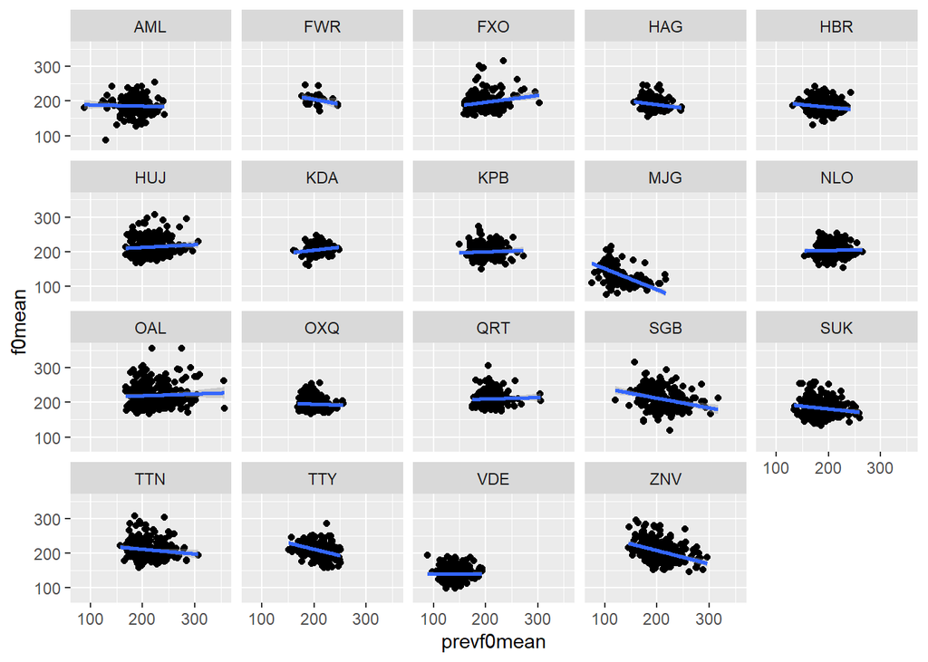

```r
for(d in unique(dat$dyad)){
  r <- cor.test(dat$f0mean[dat$dyad==d], dat$prevf0mean[dat$dyad==d], method="pearson")
  ggplot(dat %>% filter(dyad==d), aes(prevf0mean, f0mean))+
           geom_point()+
           geom_smooth(method="lm")+
    ggtitle(paste0(ifelse(dat$condition[dat$dyad==d]=="exp", "Close", "Impersonal"), " - r = ", r$estimate, ", p = ", r$p.value))+
    facet_wrap(~order)
  ggsave(filename = paste0(here::here(), "/figures/individualEffects/", d, ".png"),
         dpi = "retina")
}
ggplot(dat, aes(prevf0mean, f0mean))+
  geom_point()+
  geom_smooth(method="lm")+
  facet_wrap(~dyad)
```

### f0 SD

# Grouped

## f0 averaged over each IPU

### f0 mean

Similar results if we look at *order* or at *turn*.

```r
summary(lmer(f0mean ~ prevf0meanC * order + (1|speaker), dat))
```

```
## Linear mixed model fit by REML. t-tests use Satterthwaite's method [
## lmerModLmerTest]
## Formula: f0mean ~ prevf0meanC * order + (1 | speaker)
##    Data: dat
##
## REML criterion at convergence: 60494.6
##
## Scaled residuals:
##     Min      1Q  Median      3Q     Max
## -4.5376 -0.6317 -0.1095  0.5048  6.5060
##
## Random effects:
##  Groups   Name        Variance Std.Dev.
##  speaker  (Intercept) 592.1    24.33
##  Residual             491.7    22.17
## Number of obs: 6672, groups:  speaker, 38
##
## Fixed effects:
##                     Estimate Std. Error         df t value Pr(>|t|)
## (Intercept)        199.90446    4.05679   40.84120  49.276  < 2e-16 ***
## prevf0meanC          0.10992    0.04006 6632.04818   2.744  0.00609 **
## order               -1.53359    0.26586 6635.53560  -5.768 8.36e-09 ***
## prevf0meanC:order   -0.01576    0.01199 6632.15030  -1.315  0.18860
## ---
## Signif. codes:  0 '***' 0.001 '**' 0.01 '*' 0.05 '.' 0.1 ' ' 1
##
## Correlation of Fixed Effects:
##             (Intr) prvf0C order
## prevf0meanC -0.022
## order       -0.220  0.076
## prvf0mnC:rd  0.017 -0.953 -0.052
```

```r
summary(lmer(f0mean ~ prevf0meanC * turn + (1|speaker), dat))
```

```
## Linear mixed model fit by REML. t-tests use Satterthwaite's method [
## lmerModLmerTest]
## Formula: f0mean ~ prevf0meanC * turn + (1 | speaker)
##    Data: dat
##
## REML criterion at convergence: 60536.4
##
## Scaled residuals:
##     Min      1Q  Median      3Q     Max
## -4.5309 -0.6285 -0.1174  0.5008  6.4974
##
## Random effects:
##  Groups   Name        Variance Std.Dev.
##  speaker  (Intercept) 598.5    24.46
##  Residual             493.8    22.22
## Number of obs: 6672, groups:  speaker, 38
##
## Fixed effects:
##                    Estimate Std. Error         df t value Pr(>|t|)
## (Intercept)       1.954e+02  3.989e+00  3.735e+01  48.985  < 2e-16 ***
## prevf0meanC       8.340e-02  1.670e-02  6.631e+03   4.994 6.06e-07 ***
## turn             -2.105e-02  9.655e-03  6.637e+03  -2.180   0.0293 *
## prevf0meanC:turn -7.121e-04  4.412e-04  6.632e+03  -1.614   0.1066
## ---
## Signif. codes:  0 '***' 0.001 '**' 0.01 '*' 0.05 '.' 0.1 ' ' 1
##
## Correlation of Fixed Effects:
##             (Intr) prvf0C turn
## prevf0meanC -0.003
## turn        -0.069  0.019
## prvf0mnC:tr  0.002 -0.691  0.015
```

#### Dividing between the two conditions

It seems that the people in the impersonal condition are driving the divergence. This is true both when looking at *order* and *turn*.

```r
summary(lmer(f0mean ~ prevf0meanC * order + (1|speaker), dat %>% filter(condition=="close")))
```

```
## Linear mixed model fit by REML. t-tests use Satterthwaite's method [
## lmerModLmerTest]
## Formula: f0mean ~ prevf0meanC * order + (1 | speaker)
##    Data: dat %>% filter(condition == "close")
##
## REML criterion at convergence: 30704.6
##
## Scaled residuals:
##     Min      1Q  Median      3Q     Max
## -3.6261 -0.6552 -0.1201  0.5295  4.2333
##
## Random effects:
##  Groups   Name        Variance Std.Dev.
##  speaker  (Intercept) 648      25.46
##  Residual             485      22.02
## Number of obs: 3391, groups:  speaker, 20
##
## Fixed effects:
##                     Estimate Std. Error         df t value Pr(>|t|)
## (Intercept)        200.69559    5.83392   20.73209  34.401  < 2e-16 ***
## prevf0meanC          0.09106    0.05717 3368.29909   1.593  0.11132
## order               -1.09126    0.36558 3371.40010  -2.985  0.00286 **
## prevf0meanC:order   -0.02007    0.01688 3368.32027  -1.189  0.23451
## ---
## Signif. codes:  0 '***' 0.001 '**' 0.01 '*' 0.05 '.' 0.1 ' ' 1
##
## Correlation of Fixed Effects:
##             (Intr) prvf0C order
## prevf0meanC -0.018
## order       -0.207  0.068
## prvf0mnC:rd  0.014 -0.954 -0.050
```

```r
summary(lmer(f0mean ~ prevf0meanC * order + (1|speaker), dat %>% filter(condition=="impersonal")))
```

```
## Linear mixed model fit by REML. t-tests use Satterthwaite's method [
## lmerModLmerTest]
## Formula: f0mean ~ prevf0meanC * order + (1 | speaker)
##    Data: dat %>% filter(condition == "impersonal")
##
## REML criterion at convergence: 29782.9
##
## Scaled residuals:
##     Min      1Q  Median      3Q     Max
## -4.4216 -0.6134 -0.0996  0.4757  6.4795
##
## Random effects:
##  Groups   Name        Variance Std.Dev.
##  speaker  (Intercept) 553.6    23.53
##  Residual             497.4    22.30
## Number of obs: 3281, groups:  speaker, 18
##
## Fixed effects:
##                     Estimate Std. Error         df t value Pr(>|t|)
## (Intercept)        1.990e+02  5.713e+00  1.896e+01  34.826  < 2e-16 ***
## prevf0meanC        1.175e-01  5.621e-02  3.261e+03   2.090   0.0367 *
## order             -1.992e+00  3.867e-01  3.261e+03  -5.151 2.75e-07 ***
## prevf0meanC:order -8.306e-03  1.705e-02  3.261e+03  -0.487   0.6261
## ---
## Signif. codes:  0 '***' 0.001 '**' 0.01 '*' 0.05 '.' 0.1 ' ' 1
##
## Correlation of Fixed Effects:
##             (Intr) prvf0C order
## prevf0meanC -0.026
## order       -0.230  0.083
## prvf0mnC:rd  0.020 -0.953 -0.054
```

```r
summary(lmer(f0mean ~ prevf0meanC * turn + (1|speaker), dat %>% filter(condition=="close")))
```

```
## Linear mixed model fit by REML. t-tests use Satterthwaite's method [
## lmerModLmerTest]
## Formula: f0mean ~ prevf0meanC * turn + (1 | speaker)
##    Data: dat %>% filter(condition == "close")
##
## REML criterion at convergence: 30728
##
## Scaled residuals:
##     Min      1Q  Median      3Q     Max
## -3.6200 -0.6611 -0.1313  0.5326  4.2351
##
## Random effects:
##  Groups   Name        Variance Std.Dev.
##  speaker  (Intercept) 654.2    25.58
##  Residual             486.5    22.06
## Number of obs: 3391, groups:  speaker, 20
##
## Fixed effects:
##                    Estimate Std. Error         df t value Pr(>|t|)
## (Intercept)       1.973e+02  5.745e+00  1.914e+01  34.337   <2e-16 ***
## prevf0meanC       3.821e-02  2.302e-02  3.368e+03   1.660    0.097 .
## turn             -6.054e-03  1.325e-02  3.371e+03  -0.457    0.648
## prevf0meanC:turn -3.448e-04  6.107e-04  3.368e+03  -0.565    0.572
## ---
## Signif. codes:  0 '***' 0.001 '**' 0.01 '*' 0.05 '.' 0.1 ' ' 1
##
## Correlation of Fixed Effects:
##             (Intr) prvf0C turn
## prevf0meanC -0.002
## turn        -0.061  0.014
## prvf0mnC:tr  0.001 -0.671  0.012
```

```r
summary(lmer(f0mean ~ prevf0meanC * turn + (1|speaker), dat %>% filter(condition=="impersonal")))
```

```
## Linear mixed model fit by REML. t-tests use Satterthwaite's method [
## lmerModLmerTest]
## Formula: f0mean ~ prevf0meanC * turn + (1 | speaker)
##    Data: dat %>% filter(condition == "impersonal")
##
## REML criterion at convergence: 29812.9
##
## Scaled residuals:
##     Min      1Q  Median      3Q     Max
## -4.4318 -0.6124 -0.0979  0.4707  6.4646
##
## Random effects:
##  Groups   Name        Variance Std.Dev.
##  speaker  (Intercept) 560.0    23.66
##  Residual             499.9    22.36
## Number of obs: 3281, groups:  speaker, 18
##
## Fixed effects:
##                    Estimate Std. Error         df t value Pr(>|t|)
## (Intercept)       1.933e+02  5.608e+00  1.720e+01  34.471  < 2e-16 ***
## prevf0meanC       1.306e-01  2.423e-02  3.260e+03   5.393 7.44e-08 ***
## turn             -3.689e-02  1.406e-02  3.262e+03  -2.623  0.00875 **
## prevf0meanC:turn -1.190e-03  6.376e-04  3.261e+03  -1.867  0.06203 .
## ---
## Signif. codes:  0 '***' 0.001 '**' 0.01 '*' 0.05 '.' 0.1 ' ' 1
##
## Correlation of Fixed Effects:
##             (Intr) prvf0C turn
## prevf0meanC -0.004
## turn        -0.076  0.024
## prvf0mnC:tr  0.002 -0.710  0.017
```

### f0 SD

Looking at *order*: people diverged on f0 SD over time.

Looking at *turn*: people had higher f0 SD over turns within one conversation, but it was independent of the interlocutor’s f0 SD.

```r
summary(lmer(f0sd ~ prevf0sdC * order + (1|speaker), dat))
```

```
## Linear mixed model fit by REML. t-tests use Satterthwaite's method [
## lmerModLmerTest]
## Formula: f0sd ~ prevf0sdC * order + (1 | speaker)
##    Data: dat
##
## REML criterion at convergence: 45037.2
##
## Scaled residuals:
##     Min      1Q  Median      3Q     Max
## -2.3073 -0.6996 -0.1847  0.4831  6.4714
##
## Random effects:
##  Groups   Name        Variance Std.Dev.
##  speaker  (Intercept)  7.224   2.688
##  Residual             77.336   8.794
## Number of obs: 6251, groups:  speaker, 38
##
## Fixed effects:
##                   Estimate Std. Error         df t value Pr(>|t|)
## (Intercept)       10.96778    0.57763   98.62567  18.988  < 2e-16 ***
## prevf0sdC          0.11216    0.04248 6230.16226   2.640  0.00831 **
## order              0.78165    0.10818 6242.39492   7.225 5.59e-13 ***
## prevf0sdC:order   -0.02692    0.01184 6231.07399  -2.274  0.02301 *
## ---
## Signif. codes:  0 '***' 0.001 '**' 0.01 '*' 0.05 '.' 0.1 ' ' 1
##
## Correlation of Fixed Effects:
##             (Intr) prvf0C order
## prevf0sdC    0.015
## order       -0.624 -0.003
## prvf0sdC:rd  0.000 -0.956 -0.021
```

```r
summary(lmer(f0sd ~ prevf0sdC * turn + (1|speaker), dat))
```

```
## Linear mixed model fit by REML. t-tests use Satterthwaite's method [
## lmerModLmerTest]
## Formula: f0sd ~ prevf0sdC * turn + (1 | speaker)
##    Data: dat
##
## REML criterion at convergence: 45062.2
##
## Scaled residuals:
##     Min      1Q  Median      3Q     Max
## -2.3177 -0.6988 -0.1902  0.4921  6.4621
##
## Random effects:
##  Groups   Name        Variance Std.Dev.
##  speaker  (Intercept)  7.206   2.684
##  Residual             77.482   8.802
## Number of obs: 6251, groups:  speaker, 38
##
## Fixed effects:
##                  Estimate Std. Error         df t value Pr(>|t|)
## (Intercept)     1.282e+01  4.645e-01  4.153e+01  27.589  < 2e-16 ***
## prevf0sdC       3.385e-02  1.815e-02  6.218e+03   1.865   0.0623 .
## turn            2.619e-02  3.926e-03  6.246e+03   6.669 2.79e-11 ***
## prevf0sdC:turn -3.947e-04  4.156e-04  6.223e+03  -0.950   0.3423
## ---
## Signif. codes:  0 '***' 0.001 '**' 0.01 '*' 0.05 '.' 0.1 ' ' 1
##
## Correlation of Fixed Effects:
##             (Intr) prvf0C turn
## prevf0sdC    0.015
## turn        -0.240 -0.020
## prvf0sdC:tr -0.006 -0.726 -0.037
```

#### Dividing between the two conditions

Same as with f0 mean: divergence on f0 SD (when looking at *order*), it were the dyads in the impersonal condition that drove the divergence.

```r
summary(lmer(f0sd ~ prevf0sdC * order + (1|speaker), dat %>% filter(condition=="close")))
```

```
## Linear mixed model fit by REML. t-tests use Satterthwaite's method [
## lmerModLmerTest]
## Formula: f0sd ~ prevf0sdC * order + (1 | speaker)
##    Data: dat %>% filter(condition == "close")
##
## REML criterion at convergence: 22345.1
##
## Scaled residuals:
##     Min      1Q  Median      3Q     Max
## -2.4851 -0.6867 -0.1688  0.5127  5.2751
##
## Random effects:
##  Groups   Name        Variance Std.Dev.
##  speaker  (Intercept)  8.945   2.991
##  Residual             69.916   8.362
## Number of obs: 3144, groups:  speaker, 20
##
## Fixed effects:
##                   Estimate Std. Error         df t value Pr(>|t|)
## (Intercept)      9.815e+00  8.341e-01  4.106e+01  11.767 9.83e-15 ***
## prevf0sdC       -4.171e-02  6.208e-02  3.128e+03  -0.672    0.502
## order            1.076e+00  1.434e-01  3.140e+03   7.504 8.02e-14 ***
## prevf0sdC:order  8.308e-03  1.722e-02  3.128e+03   0.482    0.630
## ---
## Signif. codes:  0 '***' 0.001 '**' 0.01 '*' 0.05 '.' 0.1 ' ' 1
##
## Correlation of Fixed Effects:
##             (Intr) prvf0C order
## prevf0sdC    0.038
## order       -0.565 -0.035
## prvf0sdC:rd -0.021 -0.960  0.002
```

```r
summary(lmer(f0sd ~ prevf0sdC * order + (1|speaker), dat %>% filter(condition=="impersonal")))
```

```
## Linear mixed model fit by REML. t-tests use Satterthwaite's method [
## lmerModLmerTest]
## Formula: f0sd ~ prevf0sdC * order + (1 | speaker)
##    Data: dat %>% filter(condition == "impersonal")
##
## REML criterion at convergence: 22656.4
##
## Scaled residuals:
##     Min      1Q  Median      3Q     Max
## -1.7481 -0.7079 -0.1982  0.4663  5.9489
##
## Random effects:
##  Groups   Name        Variance Std.Dev.
##  speaker  (Intercept)  5.799   2.408
##  Residual             84.465   9.191
## Number of obs: 3107, groups:  speaker, 18
##
## Fixed effects:
##                   Estimate Std. Error         df t value Pr(>|t|)
## (Intercept)       12.09789    0.80769   58.91101  14.978  < 2e-16 ***
## prevf0sdC          0.21917    0.05851 3098.52126   3.746 0.000183 ***
## order              0.49656    0.16278 3092.75636   3.050 0.002304 **
## prevf0sdC:order   -0.05077    0.01636 3099.16810  -3.103 0.001934 **
## ---
## Signif. codes:  0 '***' 0.001 '**' 0.01 '*' 0.05 '.' 0.1 ' ' 1
##
## Correlation of Fixed Effects:
##             (Intr) prvf0C order
## prevf0sdC   -0.011
## order       -0.681  0.026
## prvf0sdC:rd  0.020 -0.952 -0.040
```

## f0 averaged over each turn

### f0 mean

Looking at *order*, people diverged on f0 mean over the tasks.

Looking at *turn*, there was no effect.

```r
dat <- dat %>%
  group_by(speaker, task) %>%
  filter(!duplicated(turn)) %>%
  ungroup()

summary(lmer(turnf0mean ~ prevTurnf0meanC * order + (1|speaker), dat))
```

```
## Linear mixed model fit by REML. t-tests use Satterthwaite's method [
## lmerModLmerTest]
## Formula: turnf0mean ~ prevTurnf0meanC * order + (1 | speaker)
##    Data: dat
##
## REML criterion at convergence: 40074.4
##
## Scaled residuals:
##     Min      1Q  Median      3Q     Max
## -4.3337 -0.6111 -0.0750  0.5059  5.7006
##
## Random effects:
##  Groups   Name        Variance Std.Dev.
##  speaker  (Intercept) 596.8    24.43
##  Residual             325.6    18.04
## Number of obs: 4623, groups:  speaker, 38
##
## Fixed effects:
##                         Estimate Std. Error         df t value Pr(>|t|)
## (Intercept)            202.09783    4.11166   42.49851  49.152  < 2e-16 ***
## prevTurnf0meanC          0.13668    0.05987 4582.96227   2.283   0.0225 *
## order                   -1.97405    0.29265 4588.36725  -6.746 1.71e-11 ***
## prevTurnf0meanC:order   -0.02113    0.01603 4583.12228  -1.318   0.1876
## ---
## Signif. codes:  0 '***' 0.001 '**' 0.01 '*' 0.05 '.' 0.1 ' ' 1
##
## Correlation of Fixed Effects:
##             (Intr) prvT0C order
## prvTrnf0mnC -0.050
## order       -0.256  0.167
## prvTrnf0mC:  0.044 -0.969 -0.141
```

```r
summary(lmer(turnf0mean ~ prevTurnf0meanC * turn + (1|speaker), dat))
```

```
## Linear mixed model fit by REML. t-tests use Satterthwaite's method [
## lmerModLmerTest]
## Formula: turnf0mean ~ prevTurnf0meanC * turn + (1 | speaker)
##    Data: dat
##
## REML criterion at convergence: 40130.8
##
## Scaled residuals:
##     Min      1Q  Median      3Q     Max
## -4.3652 -0.6241 -0.0761  0.5045  5.7026
##
## Random effects:
##  Groups   Name        Variance Std.Dev.
##  speaker  (Intercept) 604.7    24.59
##  Residual             328.6    18.13
## Number of obs: 4623, groups:  speaker, 38
##
## Fixed effects:
##                        Estimate Std. Error         df t value Pr(>|t|)
## (Intercept)           1.959e+02  4.013e+00  3.757e+01  48.817  < 2e-16 ***
## prevTurnf0meanC       8.683e-02  2.300e-02  4.582e+03   3.776 0.000162 ***
## turn                 -2.507e-02  9.412e-03  4.588e+03  -2.664 0.007757 **
## prevTurnf0meanC:turn -4.520e-04  5.036e-04  4.583e+03  -0.898 0.369406
## ---
## Signif. codes:  0 '***' 0.001 '**' 0.01 '*' 0.05 '.' 0.1 ' ' 1
##
## Correlation of Fixed Effects:
##             (Intr) prvT0C turn
## prvTrnf0mnC -0.003
## turn        -0.078  0.020
## prvTrnf0mC:  0.002 -0.770  0.014
```

#### Dividing between the two conditions

Again, people in the impersonal condition drove the divergence effect.

```r
summary(lmer(turnf0mean ~ prevTurnf0meanC * order + (1|speaker), dat %>% filter(condition=="close")))
```

```
## Linear mixed model fit by REML. t-tests use Satterthwaite's method [
## lmerModLmerTest]
## Formula: turnf0mean ~ prevTurnf0meanC * order + (1 | speaker)
##    Data: dat %>% filter(condition == "close")
##
## REML criterion at convergence: 19152.2
##
## Scaled residuals:
##     Min      1Q  Median      3Q     Max
## -4.3132 -0.6282 -0.0770  0.5295  5.1754
##
## Random effects:
##  Groups   Name        Variance Std.Dev.
##  speaker  (Intercept) 646.8    25.43
##  Residual             317.3    17.81
## Number of obs: 2215, groups:  speaker, 20
##
## Fixed effects:
##                         Estimate Std. Error         df t value Pr(>|t|)
## (Intercept)            202.24735    5.88333   21.57841  34.376  < 2e-16 ***
## prevTurnf0meanC          0.06436    0.09462 2192.38990   0.680  0.49645
## order                   -1.30876    0.40371 2196.79307  -3.242  0.00121 **
## prevTurnf0meanC:order   -0.01269    0.02461 2192.42358  -0.515  0.60632
## ---
## Signif. codes:  0 '***' 0.001 '**' 0.01 '*' 0.05 '.' 0.1 ' ' 1
##
## Correlation of Fixed Effects:
##             (Intr) prvT0C order
## prvTrnf0mnC -0.045
## order       -0.243  0.157
## prvTrnf0mC:  0.041 -0.974 -0.140
```

```r
summary(lmer(turnf0mean ~ prevTurnf0meanC * order + (1|speaker), dat %>% filter(condition=="impersonal")))
```

```
## Linear mixed model fit by REML. t-tests use Satterthwaite's method [
## lmerModLmerTest]
## Formula: turnf0mean ~ prevTurnf0meanC * order + (1 | speaker)
##    Data: dat %>% filter(condition == "impersonal")
##
## REML criterion at convergence: 20910.5
##
## Scaled residuals:
##     Min      1Q  Median      3Q     Max
## -4.2407 -0.6097 -0.0717  0.5005  5.6440
##
## Random effects:
##  Groups   Name        Variance Std.Dev.
##  speaker  (Intercept) 562.2    23.71
##  Residual             331.7    18.21
## Number of obs: 2408, groups:  speaker, 18
##
## Fixed effects:
##                         Estimate Std. Error         df t value Pr(>|t|)
## (Intercept)            201.88695    5.80947   19.68689  34.751  < 2e-16 ***
## prevTurnf0meanC          0.15229    0.07801 2387.51863   1.952    0.051 .
## order                   -2.66964    0.42302 2387.55463  -6.311  3.3e-10 ***
## prevTurnf0meanC:order   -0.01638    0.02143 2387.67107  -0.764    0.445
## ---
## Signif. codes:  0 '***' 0.001 '**' 0.01 '*' 0.05 '.' 0.1 ' ' 1
##
## Correlation of Fixed Effects:
##             (Intr) prvT0C order
## prvTrnf0mnC -0.054
## order       -0.265  0.175
## prvTrnf0mC:  0.046 -0.966 -0.141
```

### f0 SD

Looking at *order*, people diverged on f0 SD over the tasks.

Looking at *turn*, people also diverged on f0 SD over turns, but with a small effect size.

```r
summary(lmer(turnf0sd ~ prevTurnf0sdC * order + (1|speaker), dat))
```

```
## Linear mixed model fit by REML. t-tests use Satterthwaite's method [
## lmerModLmerTest]
## Formula: turnf0sd ~ prevTurnf0sdC * order + (1 | speaker)
##    Data: dat
##
## REML criterion at convergence: 30976.1
##
## Scaled residuals:
##     Min      1Q  Median      3Q     Max
## -2.5945 -0.6490 -0.1636  0.4612  6.4100
##
## Random effects:
##  Groups   Name        Variance Std.Dev.
##  speaker  (Intercept)  8.249   2.872
##  Residual             63.179   7.949
## Number of obs: 4419, groups:  speaker, 38
##
## Fixed effects:
##                       Estimate Std. Error         df t value Pr(>|t|)
## (Intercept)           11.43533    0.66707  134.18237  17.143  < 2e-16 ***
## prevTurnf0sdC          0.27333    0.06413 4398.71740   4.262 2.07e-05 ***
## order                  0.76313    0.12814 4411.20381   5.955 2.80e-09 ***
## prevTurnf0sdC:order   -0.06210    0.01658 4400.11744  -3.745 0.000183 ***
## ---
## Signif. codes:  0 '***' 0.001 '**' 0.01 '*' 0.05 '.' 0.1 ' ' 1
##
## Correlation of Fixed Effects:
##             (Intr) prvT0C order
## prvTrnf0sdC -0.017
## order       -0.687  0.036
## prvTrnf0sC:  0.027 -0.972 -0.053
```

```r
summary(lmer(turnf0sd ~ prevTurnf0sdC * turn + (1|speaker), dat))
```

```
## Linear mixed model fit by REML. t-tests use Satterthwaite's method [
## lmerModLmerTest]
## Formula: turnf0sd ~ prevTurnf0sdC * turn + (1 | speaker)
##    Data: dat
##
## REML criterion at convergence: 31025.1
##
## Scaled residuals:
##     Min      1Q  Median      3Q     Max
## -2.5820 -0.6579 -0.1708  0.4504  6.5081
##
## Random effects:
##  Groups   Name        Variance Std.Dev.
##  speaker  (Intercept)  8.347   2.889
##  Residual             63.682   7.980
## Number of obs: 4419, groups:  speaker, 38
##
## Fixed effects:
##                      Estimate Std. Error         df t value Pr(>|t|)
## (Intercept)         1.378e+01  5.074e-01  4.378e+01  27.165  < 2e-16 ***
## prevTurnf0sdC       8.848e-02  2.413e-02  4.384e+03   3.668 0.000248 ***
## turn                1.093e-02  4.194e-03  4.415e+03   2.606 0.009182 **
## prevTurnf0sdC:turn -1.177e-03  5.048e-04  4.389e+03  -2.333 0.019719 *
## ---
## Signif. codes:  0 '***' 0.001 '**' 0.01 '*' 0.05 '.' 0.1 ' ' 1
##
## Correlation of Fixed Effects:
##             (Intr) prvT0C turn
## prvTrnf0sdC -0.003
## turn        -0.279  0.004
## prvTrnf0sC:  0.002 -0.778 -0.029
```

#### Dividing between the two conditions

Here, looking at *order*, same pattern as before (impersonal condition driving divergence).

Looking at *turn*, it’s the other way around, but with a very small effect size.

```r
summary(lmer(turnf0sd ~ prevTurnf0sdC * order + (1|speaker), dat %>% filter(condition=="close")))
```

```
## Linear mixed model fit by REML. t-tests use Satterthwaite's method [
## lmerModLmerTest]
## Formula: turnf0sd ~ prevTurnf0sdC * order + (1 | speaker)
##    Data: dat %>% filter(condition == "close")
##
## REML criterion at convergence: 14447.5
##
## Scaled residuals:
##     Min      1Q  Median      3Q     Max
## -2.8140 -0.6364 -0.1420  0.4625  5.7280
##
## Random effects:
##  Groups   Name        Variance Std.Dev.
##  speaker  (Intercept) 10.17    3.190
##  Residual             56.09    7.489
## Number of obs: 2095, groups:  speaker, 20
##
## Fixed effects:
##                       Estimate Std. Error         df t value Pr(>|t|)
## (Intercept)          1.024e+01  9.539e-01  5.450e+01  10.733 4.68e-15 ***
## prevTurnf0sdC       -3.087e-02  1.067e-01  2.084e+03  -0.289    0.772
## order                1.098e+00  1.704e-01  2.091e+03   6.445 1.43e-10 ***
## prevTurnf0sdC:order  8.474e-03  2.695e-02  2.084e+03   0.314    0.753
## ---
## Signif. codes:  0 '***' 0.001 '**' 0.01 '*' 0.05 '.' 0.1 ' ' 1
##
## Correlation of Fixed Effects:
##             (Intr) prvT0C order
## prvTrnf0sdC  0.048
## order       -0.632 -0.057
## prvTrnf0sC: -0.035 -0.979  0.031
```

```r
summary(lmer(turnf0sd ~ prevTurnf0sdC * order + (1|speaker), dat %>% filter(condition=="impersonal")))
```

```
## Linear mixed model fit by REML. t-tests use Satterthwaite's method [
## lmerModLmerTest]
## Formula: turnf0sd ~ prevTurnf0sdC * order + (1 | speaker)
##    Data: dat %>% filter(condition == "impersonal")
##
## REML criterion at convergence: 16497.1
##
## Scaled residuals:
##     Min      1Q  Median      3Q     Max
## -2.0402 -0.6696 -0.1861  0.4592  5.8324
##
## Random effects:
##  Groups   Name        Variance Std.Dev.
##  speaker  (Intercept)  6.743   2.597
##  Residual             69.199   8.319
## Number of obs: 2324, groups:  speaker, 18
##
## Fixed effects:
##                       Estimate Std. Error         df t value Pr(>|t|)
## (Intercept)           12.42118    0.94058   79.25656  13.206  < 2e-16 ***
## prevTurnf0sdC          0.39655    0.08196 2313.85530   4.838 1.40e-06 ***
## order                  0.48450    0.19159 2309.77710   2.529   0.0115 *
## prevTurnf0sdC:order   -0.09023    0.02156 2314.97388  -4.185 2.96e-05 ***
## ---
## Signif. codes:  0 '***' 0.001 '**' 0.01 '*' 0.05 '.' 0.1 ' ' 1
##
## Correlation of Fixed Effects:
##             (Intr) prvT0C order
## prvTrnf0sdC -0.069
## order       -0.736  0.096
## prvTrnf0sC:  0.074 -0.967 -0.104
```

```r
summary(lmer(turnf0sd ~ prevTurnf0sdC * turn + (1|speaker), dat %>% filter(condition=="close")))
```

```
## Linear mixed model fit by REML. t-tests use Satterthwaite's method [
## lmerModLmerTest]
## Formula: turnf0sd ~ prevTurnf0sdC * turn + (1 | speaker)
##    Data: dat %>% filter(condition == "close")
##
## REML criterion at convergence: 14494
##
## Scaled residuals:
##     Min      1Q  Median      3Q     Max
## -2.7082 -0.6245 -0.1555  0.4388  5.7601
##
## Random effects:
##  Groups   Name        Variance Std.Dev.
##  speaker  (Intercept) 10.20    3.194
##  Residual             56.98    7.548
## Number of obs: 2095, groups:  speaker, 20
##
## Fixed effects:
##                      Estimate Std. Error         df t value Pr(>|t|)
## (Intercept)         1.367e+01  7.636e-01  2.197e+01  17.900 1.38e-14 ***
## prevTurnf0sdC       6.509e-02  3.541e-02  2.075e+03   1.838   0.0662 .
## turn                1.407e-02  5.657e-03  2.091e+03   2.488   0.0129 *
## prevTurnf0sdC:turn -1.265e-03  7.428e-04  2.077e+03  -1.702   0.0888 .
## ---
## Signif. codes:  0 '***' 0.001 '**' 0.01 '*' 0.05 '.' 0.1 ' ' 1
##
## Correlation of Fixed Effects:
##             (Intr) prvT0C turn
## prvTrnf0sdC -0.008
## turn        -0.244  0.013
## prvTrnf0sC:  0.005 -0.787 -0.048
```

```r
summary(lmer(turnf0sd ~ prevTurnf0sdC * turn + (1|speaker), dat %>% filter(condition=="impersonal")))
```

```
## Linear mixed model fit by REML. t-tests use Satterthwaite's method [
## lmerModLmerTest]
## Formula: turnf0sd ~ prevTurnf0sdC * turn + (1 | speaker)
##    Data: dat %>% filter(condition == "impersonal")
##
## REML criterion at convergence: 16528.5
##
## Scaled residuals:
##     Min      1Q  Median      3Q     Max
## -1.9429 -0.6835 -0.1903  0.4559  6.1697
##
## Random effects:
##  Groups   Name        Variance Std.Dev.
##  speaker  (Intercept)  6.809   2.609
##  Residual             69.726   8.350
## Number of obs: 2324, groups:  speaker, 18
##
## Fixed effects:
##                      Estimate Std. Error         df t value Pr(>|t|)
## (Intercept)         1.390e+01  6.736e-01  2.071e+01  20.633 2.75e-15 ***
## prevTurnf0sdC       1.062e-01  3.302e-02  2.307e+03   3.217  0.00131 **
## turn                7.898e-03  6.164e-03  2.319e+03   1.281  0.20022
## prevTurnf0sdC:turn -1.114e-03  6.897e-04  2.309e+03  -1.615  0.10637
## ---
## Signif. codes:  0 '***' 0.001 '**' 0.01 '*' 0.05 '.' 0.1 ' ' 1
##
## Correlation of Fixed Effects:
##             (Intr) prvT0C turn
## prvTrnf0sdC  0.004
## turn        -0.315 -0.002
## prvTrnf0sC:  0.000 -0.771 -0.014
```